# Medical Insurance Cost — Exploratory Data Analysis

This notebook explores the *Medical Cost Personal Dataset*, which contains demographic and lifestyle features for 1 338 insurance beneficiaries alongside their annual medical charges.

| Column | Type | Description |
| --- | --- | --- |
| `age` | int | Age of the primary beneficiary |
| `sex` | category | Biological sex (`male` / `female`) |
| `bmi` | float | Body Mass Index |
| `children` | int | Number of dependants covered |
| `smoker` | category | Smoking status (`yes` / `no`) |
| `region` | category | US residential region |
| `charges` | float | Individual medical costs billed (target) |

**Prerequisite:** Before running this notebook, make sure the raw data file exists at `data/insurance.csv`. If it doesn't, run the ingestion script from the project root first:

```
    python scripts/ingest_data.py
```

**Outputs:** All figures are automatically saved to `reports/figures/`. Running the final cell exports this notebook as a self-contained HTML report to `reports/eda_report.html`.

## 1. Setup

```python
import subprocess, sys
import warnings
warnings.filterwarnings('ignore')

from pathlib import Path

import numpy as np
import pandas as pd
import matplotlib.pyplot as plt
import seaborn as sns

sns.set_theme(style='whitegrid', palette='PiYG')
plt.rcParams['figure.dpi'] = 110

DATA_PATH = Path('..') / 'data' / 'insurance.csv'

# Output directories
FIGURES_DIR = Path('..') / 'reports' / 'figures'
REPORTS_DIR = Path('..') / 'reports'
FIGURES_DIR.mkdir(parents=True, exist_ok=True)
REPORTS_DIR.mkdir(parents=True, exist_ok=True)
```

## 2. Load Data

```python
df = pd.read_csv(DATA_PATH)

# Casting categorical columns
for col in ['sex', 'smoker', 'region']:
    df[col] = df[col].astype('category')

print(f'Shape: {df.shape}')
df.head()
```

```
Shape: (1338, 7)
```

|  | age | sex | bmi | children | smoker | region | charges |
| --- | --- | --- | --- | --- | --- | --- | --- |
| 0 | 19 | female | 27.900 | 0 | yes | southwest | 16884.92400 |
| 1 | 18 | male | 33.770 | 1 | no | southeast | 1725.55230 |
| 2 | 28 | male | 33.000 | 3 | no | southeast | 4449.46200 |
| 3 | 33 | male | 22.705 | 0 | no | northwest | 21984.47061 |
| 4 | 32 | male | 28.880 | 0 | no | northwest | 3866.85520 |

## 3. Data Quality

```python
print('--- Data Types ---')
print(df.dtypes)
print()
print('--- Missing Values ---')
print(df.isnull().sum())
print()
print('--- Duplicate Rows ---')
print(df.duplicated().sum())
```

```
--- Data Types ---
age            int64
sex         category
bmi          float64
children       int64
smoker      category
region      category
charges      float64
dtype: object

--- Missing Values ---
age         0
sex         0
bmi         0
children    0
smoker      0
region      0
charges     0
dtype: int64

--- Duplicate Rows ---
1
```

```python
df.describe(include='all').T
```

|  | count | unique | top | freq | mean | std | min | 25% | 50% | 75% | max |
| --- | --- | --- | --- | --- | --- | --- | --- | --- | --- | --- | --- |
| age | 1338.0 | NaN | NaN | NaN | 39.207025 | 14.04996 | 18.0 | 27.0 | 39.0 | 51.0 | 64.0 |
| sex | 1338 | 2 | male | 676 | NaN | NaN | NaN | NaN | NaN | NaN | NaN |
| bmi | 1338.0 | NaN | NaN | NaN | 30.663397 | 6.098187 | 15.96 | 26.29625 | 30.4 | 34.69375 | 53.13 |
| children | 1338.0 | NaN | NaN | NaN | 1.094918 | 1.205493 | 0.0 | 0.0 | 1.0 | 2.0 | 5.0 |
| smoker | 1338 | 2 | no | 1064 | NaN | NaN | NaN | NaN | NaN | NaN | NaN |
| region | 1338 | 4 | southeast | 364 | NaN | NaN | NaN | NaN | NaN | NaN | NaN |
| charges | 1338.0 | NaN | NaN | NaN | 13270.422265 | 12110.011237 | 1121.8739 | 4740.28715 | 9382.033 | 16639.912515 | 63770.42801 |

## 4. Target Variable: `charges`

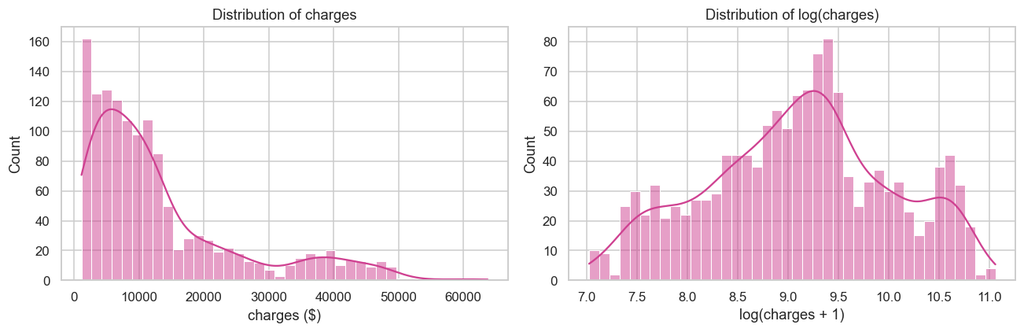

```
Skewness (raw):  1.516
Skewness (log):  -0.090
```

```python
fig, axes = plt.subplots(1, 2, figsize=(12, 4))

sns.histplot(df['charges'], bins=40, kde=True, ax=axes[0])
axes[0].set_title('Distribution of charges')
axes[0].set_xlabel('charges ($)')

sns.histplot(np.log1p(df['charges']), bins=40, kde=True, ax=axes[1])
axes[1].set_title('Distribution of log(charges)')
axes[1].set_xlabel('log(charges + 1)')

plt.tight_layout()
plt.savefig(FIGURES_DIR / 'charges_distribution.png', bbox_inches='tight')
plt.show()

print(f"Skewness (raw):  {df['charges'].skew():.3f}")
print(f"Skewness (log):  {np.log1p(df['charges']).skew():.3f}")
```

## 5. Numeric Features

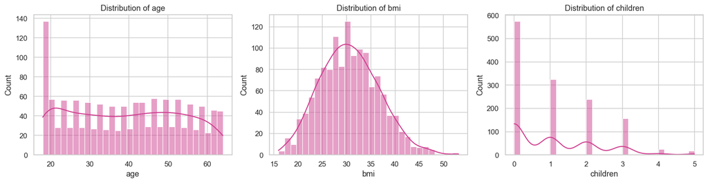

```python
numeric_cols = ['age', 'bmi', 'children']

fig, axes = plt.subplots(1, 3, figsize=(15, 4))
for ax, col in zip(axes, numeric_cols):
    sns.histplot(df[col], bins=30, kde=True, ax=ax)
    ax.set_title(f'Distribution of {col}')
plt.tight_layout()
plt.savefig(FIGURES_DIR / 'numeric_histograms.png', bbox_inches='tight')
plt.show()
```

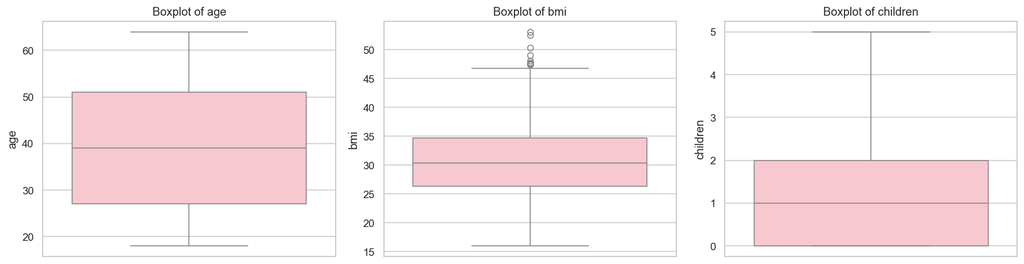

```python
fig, axes = plt.subplots(1, 3, figsize=(15, 4))
for ax, col in zip(axes, numeric_cols):
    sns.boxplot(y=df[col], ax=ax, color='pink')
    ax.set_title(f'Boxplot of {col}')
plt.tight_layout()
plt.savefig(FIGURES_DIR / 'numeric_boxplots.png', bbox_inches='tight')
plt.show()
```

## 6. Categorical Features

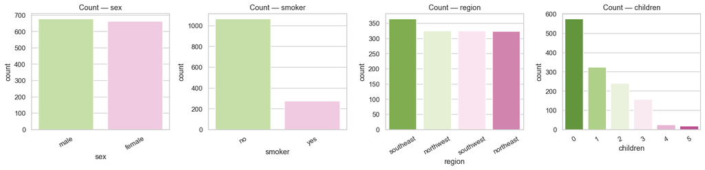

```python
cat_cols = ['sex', 'smoker', 'region', 'children']

fig, axes = plt.subplots(1, 4, figsize=(16, 4))
for ax, col in zip(axes, cat_cols):
    order = df[col].value_counts().index
    sns.countplot(data=df, x=col, order=order, ax=ax, palette='PiYG_r')
    ax.set_title(f'Count — {col}')
    ax.tick_params(axis='x', rotation=30)
plt.tight_layout()
plt.savefig(FIGURES_DIR / 'categorical_counts.png', bbox_inches='tight')
plt.show()
```

## 7. Charges by Categorical Features

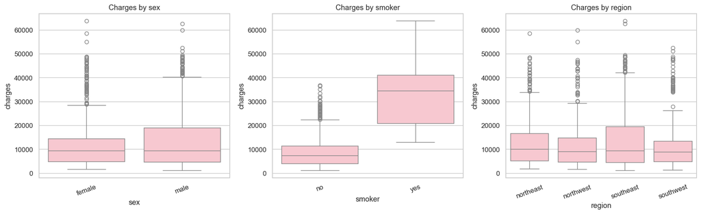

```python
fig, axes = plt.subplots(1, 3, figsize=(16, 5))

for ax, col in zip(axes, ['sex', 'smoker', 'region']):
    sns.boxplot(data=df, x=col, y='charges', ax=ax, color='pink')
    ax.set_title(f'Charges by {col}')
    ax.tick_params(axis='x', rotation=20)

plt.tight_layout()
plt.savefig(FIGURES_DIR / 'charges_by_categorical.png', bbox_inches='tight')
plt.show()
```

```python
print('Mean charges by smoker status:')
print(df.groupby('smoker', observed=True)['charges'].mean().round(2))
print()
print('Mean charges by region:')
print(df.groupby('region', observed=True)['charges'].mean().sort_values(ascending=False).round(2))
```

```
Mean charges by smoker status:
smoker
no      8434.27
yes    32050.23
Name: charges, dtype: float64

Mean charges by region:
region
southeast    14735.41
northeast    13406.38
northwest    12417.58
southwest    12346.94
Name: charges, dtype: float64
```

## 8. Charges vs Numeric Features

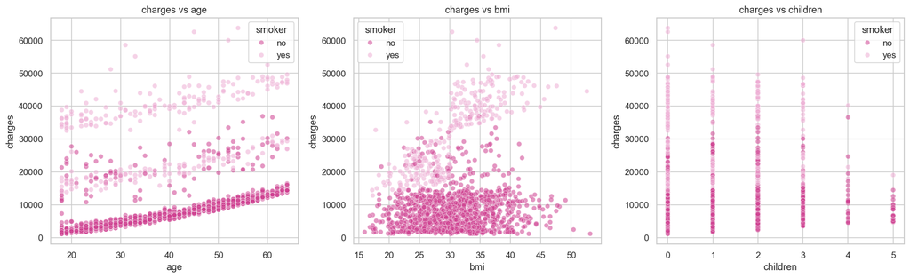

```python
fig, axes = plt.subplots(1, 3, figsize=(16, 5))

for ax, col in zip(axes, numeric_cols):
    sns.scatterplot(data=df, x=col, y='charges', hue='smoker', alpha=0.55, ax=ax)
    ax.set_title(f'charges vs {col}')

plt.tight_layout()
plt.savefig(FIGURES_DIR / 'charges_vs_numeric.png', bbox_inches='tight')
plt.show()
```

## 9. Interaction: Age × BMI × Smoker

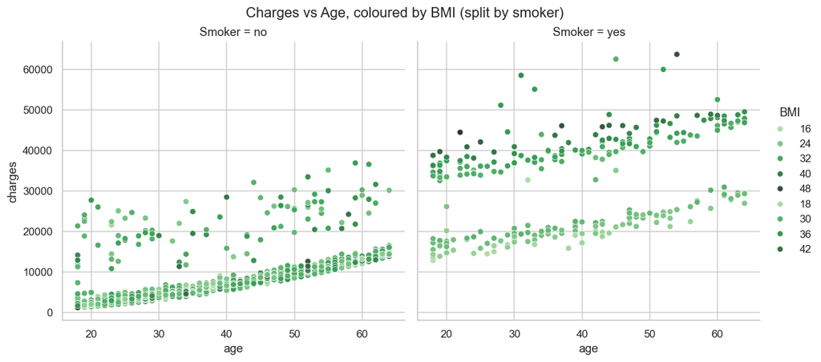

```python
g = sns.FacetGrid(df, col='smoker', height=5, aspect=1.1)
g.map_dataframe(sns.scatterplot, x='age', y='charges', hue='bmi',
                palette='Greens_d')
g.add_legend(title='BMI')
g.set_titles(col_template='Smoker = {col_name}')
plt.suptitle('Charges vs Age, coloured by BMI (split by smoker)', y=1.02)
g.savefig(FIGURES_DIR / 'age_bmi_smoker_interaction.png', bbox_inches='tight')
plt.show()
```

## 10. Correlation Analysis

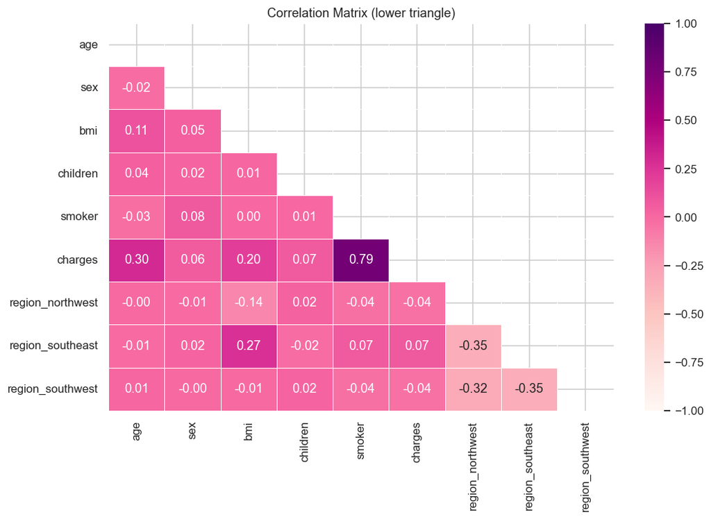

```python
df_encoded = df.copy()
df_encoded['sex'] = df_encoded['sex'].map({'male': 1, 'female': 0})
df_encoded['smoker'] = df_encoded['smoker'].map({'yes': 1, 'no': 0})
df_encoded = pd.get_dummies(df_encoded, columns=['region'], drop_first=True, dtype=int)

corr = df_encoded.corr()

plt.figure(figsize=(10, 7))
mask = np.triu(np.ones_like(corr, dtype=bool))
sns.heatmap(corr, mask=mask, annot=True, fmt='.2f', cmap='RdPu',
            vmin=-1, vmax=1, linewidths=0.5)
plt.title('Correlation Matrix (lower triangle)')
plt.tight_layout()
plt.savefig(FIGURES_DIR / 'correlation_heatmap.png', bbox_inches='tight')
plt.show()
```

```python
print('Correlation with charges (descending):')
print(corr['charges'].sort_values(ascending=False).to_string())
```

```
Correlation with charges (descending):
charges             1.000000
smoker              0.787251
age                 0.299008
bmi                 0.198341
region_southeast    0.073982
children            0.067998
sex                 0.057292
region_northwest   -0.039905
region_southwest   -0.043210
```

## 11. Pairplot

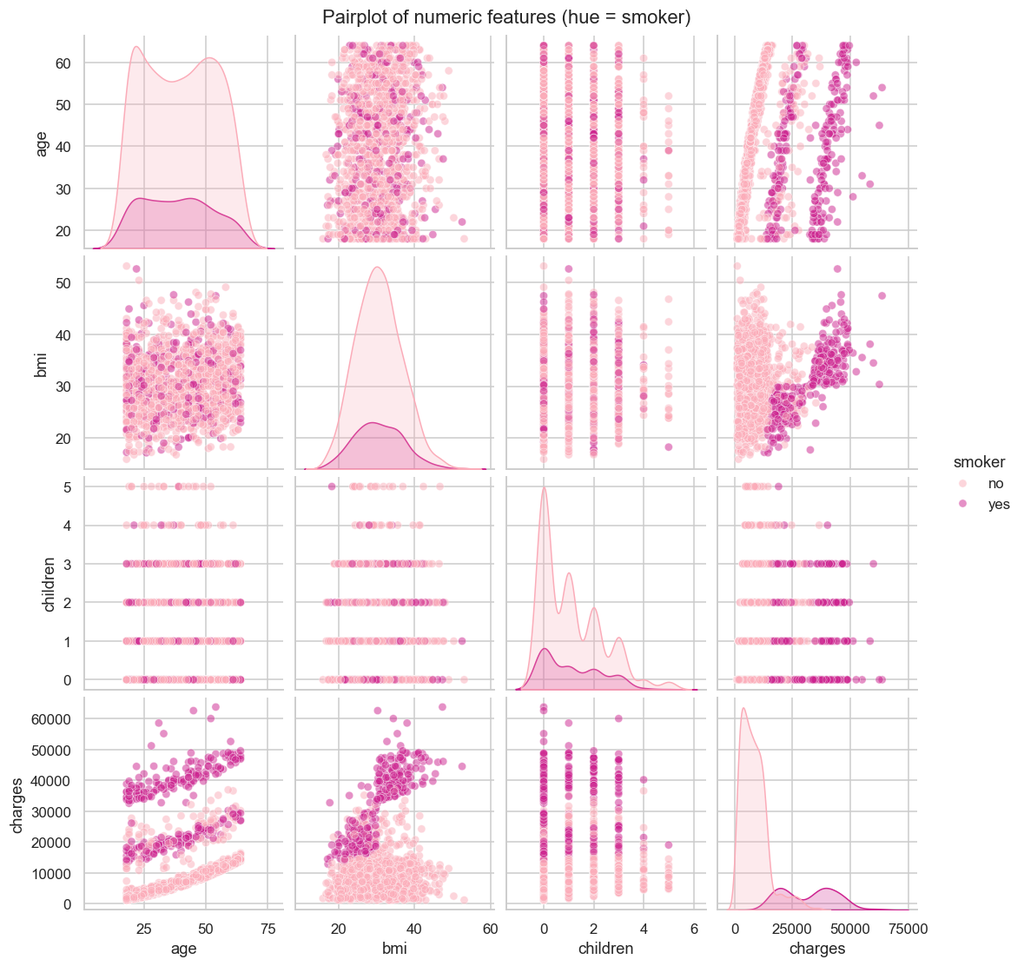

```python
g = sns.pairplot(df, hue='smoker', vars=['age', 'bmi', 'children', 'charges'],
             plot_kws={'alpha': 0.5}, diag_kind='kde', palette='RdPu')
plt.suptitle('Pairplot of numeric features (hue = smoker)', y=1.01)
g.savefig(FIGURES_DIR / 'pairplot.png', bbox_inches='tight')
plt.show()
```

## 12. Summary & Key Findings

### Dataset

- **1 338 records**, 7 columns, no missing values.
- Features: 3 numeric (`age`, `bmi`, `children`), 3 categorical (`sex`, `smoker`, `region`), 1 continuous target (`charges`).

### Target: `charges`

- Range: $1 121.87 – $63 770.43 · Mean: $13 270.42 · Median: $9 382.03
- Strongly right-skewed (skewness = 1.516). A log-transform brings it to near-normal (skewness = −0.09) - good for linear modelling.

### Feature Importance (correlation with `charges`)

| Feature | Pearson r |
| --- | --- |
| `smoker` | **0.787** |
| `age` | 0.299 |
| `bmi` | 0.198 |
| `children` | 0.068 |
| `sex` | 0.057 |
| `region` | ≤ 0.074 |

### Key Insights

- **Smoking is the strongest predictor.** Smokers pay on average $32 050 vs $8 434 for non-smokers - nearly **4× more**.
- Age is the second predictor. Charges rise linearly with age and form three parallel bands: non-smokers (low), smokers with normal BMI (medium), smokers with high BMI (high).
- The average BMI is 30.66 (at the obesity boundary). High BMI (≥ 30) alone has moderate impact. Combined with smoking, it pushes charges to the highest tier.
- Sex has negligible impact. Males average $13 957 vs females $12 570 - a difference dwarfed by smoking status.
- Region has minimal impact. The southeast is the highest-cost region ($14 735) and the southwest the lowest ($12 347), a spread of just ~$2 400.
- Most beneficiaries have 0–2 children. The correlation with charges is small (r = 0.068).

```python
# --- Quick stats referenced in the summary above ---
print("Shape:", df.shape)
print("Duplicates:", df.duplicated().sum())
print()
print(f"Charges - mean: {df['charges'].mean():.2f} | median: {df['charges'].median():.2f} "
      f"| min: {df['charges'].min():.2f} | max: {df['charges'].max():.2f}")
print(f"Charges skewness - raw: {df['charges'].skew():.3f} | "
      f"log: {np.log1p(df['charges']).skew():.3f}")
print()
print("Mean charges by smoker:")
print(df.groupby('smoker', observed=True)['charges'].mean().round(2).to_string())
print()
print("Mean charges by sex:")
print(df.groupby('sex', observed=True)['charges'].mean().round(2).to_string())
print()
print("Mean charges by region:")
print(df.groupby('region', observed=True)['charges'].mean().sort_values(ascending=False).round(2).to_string())
print()
print("Age stats:")
print(df['age'].describe().round(2).to_string())
print()
print("BMI stats:")
print(df['bmi'].describe().round(2).to_string())
print()
print("Children value counts:")
print(df['children'].value_counts().sort_index().to_string())
print()
print("Correlation with charges (descending):")
print(corr['charges'].sort_values(ascending=False).to_string())
```

```
Shape: (1338, 7)
Duplicates: 1

Charges - mean: 13270.42 | median: 9382.03 | min: 1121.87 | max: 63770.43
Charges skewness - raw: 1.516 | log: -0.090

Mean charges by smoker:
smoker
no      8434.27
yes    32050.23

Mean charges by sex:
sex
female    12569.58
male      13956.75

Mean charges by region:
region
southeast    14735.41
northeast    13406.38
northwest    12417.58
southwest    12346.94

Age stats:
count    1338.00
mean       39.21
std        14.05
min        18.00
25%        27.00
50%        39.00
75%        51.00
max        64.00

BMI stats:
count    1338.00
mean       30.66
std         6.10
min        15.96
25%        26.30
50%        30.40
75%        34.69
max        53.13

Children value counts:
children
0    574
1    324
2    240
3    157
4     25
5     18

Correlation with charges (descending):
charges             1.000000
smoker              0.787251
age                 0.299008
bmi                 0.198341
region_southeast    0.073982
children            0.067998
sex                 0.057292
region_northwest   -0.039905
region_southwest   -0.043210
```

```python
notebook_path = Path(__file__) if '__file__' in dir() else Path('eda.ipynb')
notebook_path = Path('eda.ipynb')
output_path = REPORTS_DIR / 'eda_report.html'

result = subprocess.run(
    [
        sys.executable, '-m', 'nbconvert',
        '--to', 'html',
        '--output', str(output_path.resolve()),
        str(notebook_path.resolve()),
    ],
    capture_output=True,
    text=True,
)

if result.returncode == 0:
    print(f'HTML report exported to {output_path.resolve()}')
else:
    print('nbconvert failed:')
    print(result.stderr)
```

```
HTML report exported to C:\Users\paula\Desktop\Uczelnia\medical-insurance-cost-prediction\reports\eda_report.html
```